# Regression Discontinuity Design

Nico Cardenas

2024-04-30

# Introduction to RDD

Without a random process that separates the treatment and control group, the treatment effect can be identified if the assignment to the treatment group follows a regression discontinuity design (RDD). This requires a (running) variable which, at a certain threshold, separates the observations into a treatment and control group.

# Theory of RDD

Two important variants of RDD:

- sharp RDD
  - the threshold separates the treatment and control group exactly, leaving no overlapping points
- fuzzy RDD
  - threshold influences the probability of being treated
  - instrumental variable approach ( LATE )

The value of outcome (Y) for individuals just below the threshold is missing the counter factual outcome. It increases continuously with the cut-off variable, as opposed to the treatment.

## Estimation Methods

**Three** main methods to estimate RDD can be distinguished:

- Method 1
  - select a sub-sample for which the value of the running variable is close to the threshold
  - *problem*: the smaller the sample, the larger the standard errors
- Method 2
  - select a large sample and estimate parametrically
  - *problem*: this depends on the functional forms and the polynomials
- Method 3
  - select a sub-sample close to the threshold and estimate parametrically
  - extension: different functional forms on the left and the right of the cut-off

## Advantages of RDD

Individuals near the RDD threshold cut-off are assumed to be nearly identical, expect for characteristic which are affected by the treatment.

# Replication of RDD Estimation

## Loading the dataset

##### *Abstract*

*We estimate the effect of alcohol consumption on mortality using the minimum drinking age in a regression discontinuity design. We find large and immediate increases in drinking at age 21, including a 21 percent increase in recent drinking days. We also find a discrete 9 percent increase in the mortality rate at age 21, primarily due to motor vehicle accidents, alcohol-related deaths, and suicides. We estimate a 10 percent increase in the number of drinking days for young adults results in a 4.3 percent increase in mortality. Our results suggest policies that reduce drinking among young adults can have substantial public health benefits. (JEL I12, I18)*

Let us look at the collected data.

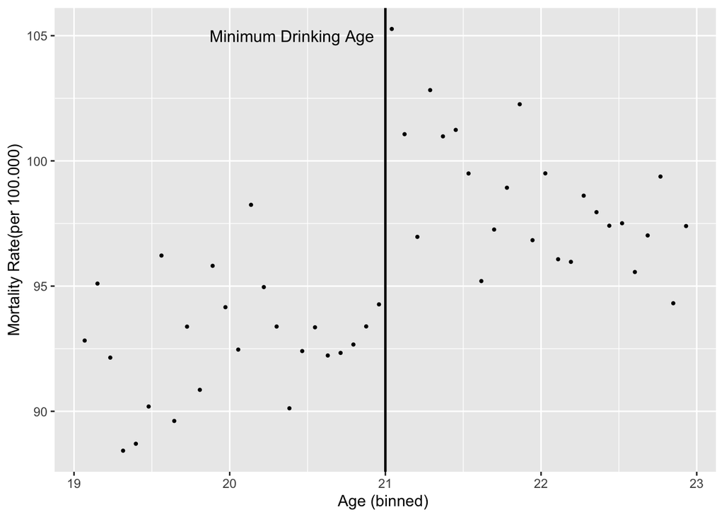

```r
load(file='/Users/nicoco/Downloads/mlda.rda')
data <- mlda

data %>%
  ggplot(aes(agecell,all)) +
  geom_point(size = 0.7) +
  geom_vline(xintercept = 21, colour = 'black',size = 0.8) +
  annotate("text", x = 20.4, y = 105, label = "Minimum Drinking Age", size = 4) +
  labs(x = "Age (binned) ", y = "Mortality Rate(per 100.000)")
```

From this graph, we can see that there is a huge jump in mortality rates after the minimum drinking age law.

## Estimation

### Model

(content) RDD can be measured by the ordinary least squares method. The first regression applies the same slope on both sides of the cut-off.

We must compute a dummy variable (`threshold`), indicating whether an individual is above or below the cut-off point. The dummy is equal to zero for observations below and equal to one of the observations above the cut-off of 21 years.

We will use a linear model using the `lm()` function to regress all deaths per 100.00 `all` against the `threshold` dummy variable and the respondent’s `age` that is around the cut-off.

```r
lm_slope <- data %>%
  mutate(threshold = ifelse(agecell >=21,1,0)) %$%
  lm(all ~ threshold + I(agecell - 21))

# Call for summary of the linear model

summary(lm_slope)
```

```
##
## Call:
## lm(formula = all ~ threshold + I(agecell - 21))
##
## Residuals:
##     Min      1Q  Median      3Q     Max
## -5.0559 -1.8483  0.1149  1.4909  5.8043
##
## Coefficients:
##                 Estimate Std. Error t value Pr(>|t|)
## (Intercept)      91.8414     0.8050 114.083  < 2e-16 ***
## threshold         7.6627     1.4403   5.320 3.15e-06 ***
## I(agecell - 21)  -0.9747     0.6325  -1.541     0.13
## ---
## Signif. codes:  0 '***' 0.001 '**' 0.01 '*' 0.05 '.' 0.1 ' ' 1
##
## Residual standard error: 2.493 on 45 degrees of freedom
##   (2 observations deleted due to missingness)
## Multiple R-squared:  0.5946, Adjusted R-squared:  0.5765
## F-statistic: 32.99 on 2 and 45 DF,  p-value: 1.508e-09
```

This approach would not alter the treatment effect. From this linear regression, we can see that on average the mortality rate per 100.000 for individuals reaching the cut-off point is **7.6627** points higher.

### Model using rddtools

This is the alternative approach using the `rddtools` package in R Studio.

```r
library(rddtools)

rdd_data(x = data$agecell,
         y = data$all,
         cutpoint = 21) %>%
  rdd_reg_lm(slope = "same") %>%
  summary()
```

```
##
## Call:
## lm(formula = y ~ ., data = dat_step1, weights = weights)
##
## Residuals:
##     Min      1Q  Median      3Q     Max
## -5.0559 -1.8483  0.1149  1.4909  5.8043
##
## Coefficients:
##             Estimate Std. Error t value Pr(>|t|)
## (Intercept)  91.8414     0.8050 114.083  < 2e-16 ***
## D             7.6627     1.4403   5.320 3.15e-06 ***
## x            -0.9747     0.6325  -1.541     0.13
## ---
## Signif. codes:  0 '***' 0.001 '**' 0.01 '*' 0.05 '.' 0.1 ' ' 1
##
## Residual standard error: 2.493 on 45 degrees of freedom
##   (2 observations deleted due to missingness)
## Multiple R-squared:  0.5946, Adjusted R-squared:  0.5765
## F-statistic: 32.99 on 2 and 45 DF,  p-value: 1.508e-09
```

Once again, looking at the coefficient on the dummy variable, we can see that on average the mortality rate per 100.000 for individuals reaching the cut-off at the minimum drinking age increases by **7.6627** points.

### Scatterplot

Let us draw a fitted line with the data on the scatter plot

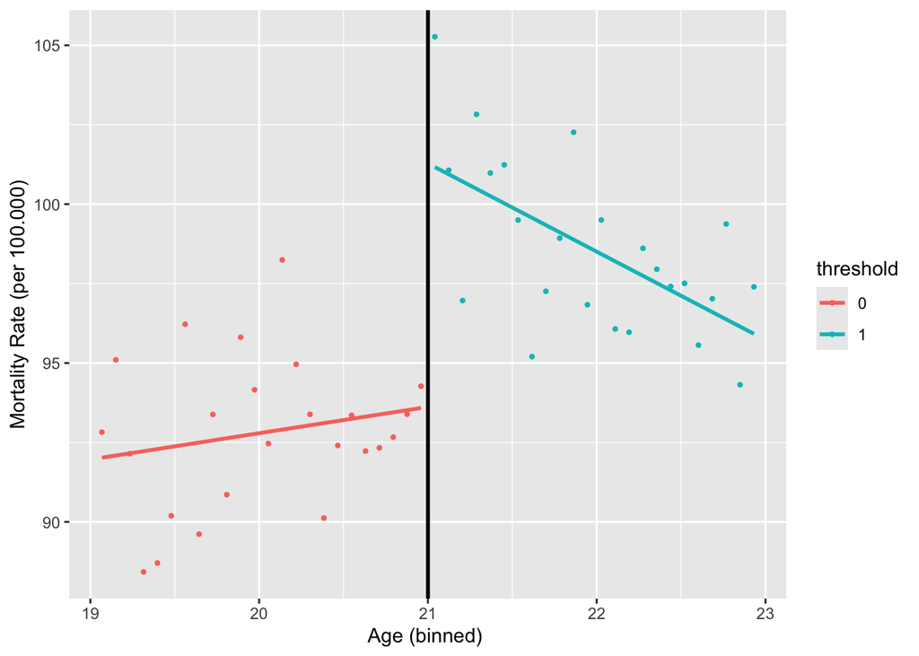

```r
data %>%
  select(agecell,all) %>%
  mutate(threshold = as.factor(ifelse(agecell>= 21,1,0))) %>%
  ggplot(aes(agecell,all, colour = threshold)) +
  geom_point(size = 0.8) +
  geom_smooth(method = lm, se = F) +
  geom_vline(xintercept = 21, colour = 'black', size = 1) +
  labs(x = "Age (binned) ", y = "Mortality Rate (per 100.000)")
```

## RDD Continued:

### Same Slope

Learning how to deal with jumps within the data. We look further into the 2009 study by Carpenter and Dobkin.

Let us look at the effect of the mortality rate in vehicle accidents based on the drinking age.

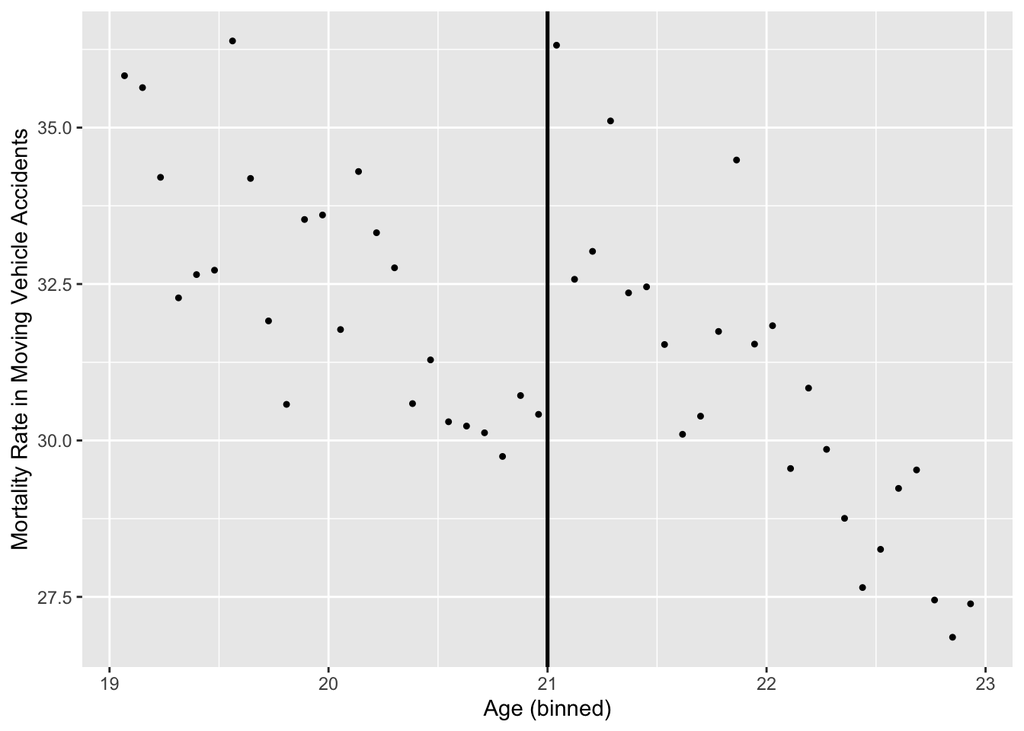

```r
data %>%
  ggplot(aes(agecell, mva)) +
  geom_point(size = 0.9) +
  geom_vline(xintercept = 21, size = 0.9, colour= 'black') +
  labs(x = "Age (binned)",
       y = "Mortality Rate in Moving Vehicle Accidents")
```

Once again, there appears to be a huge discontinuity in the points where x = 21. We can further estimate the RDD model:

$mva=\beta_{0}+\beta_{1}T+\beta_{2}(\textrm{agecell}-21)+\epsilon$

Where:

$T=\left\{ \begin{array}{cl}T=1\textrm{ if agecell is }\ge 21\\T=0\textrm{ if agecell is }<21\end{array}\right.$

Just how we performed a regression analysis with `Moratlity Rate (per 100.00)`, we will do the same with `mva`

```r
data %>%
  mutate(D = ifelse(agecell >=21,1,0)) %$%
  lm(mva ~ D + I(agecell - 21)) %>%
  summary()
```

```
##
## Call:
## lm(formula = mva ~ D + I(agecell - 21))
##
## Residuals:
##     Min      1Q  Median      3Q     Max
## -2.5318 -0.8494 -0.1800  0.7577  3.3094
##
## Coefficients:
##                 Estimate Std. Error t value Pr(>|t|)
## (Intercept)      29.3560     0.4293  68.386  < 2e-16 ***
## D                 4.5340     0.7680   5.904 4.34e-07 ***
## I(agecell - 21)  -3.1488     0.3372  -9.337 4.26e-12 ***
## ---
## Signif. codes:  0 '***' 0.001 '**' 0.01 '*' 0.05 '.' 0.1 ' ' 1
##
## Residual standard error: 1.329 on 45 degrees of freedom
##   (2 observations deleted due to missingness)
## Multiple R-squared:  0.7025, Adjusted R-squared:  0.6893
## F-statistic: 53.14 on 2 and 45 DF,  p-value: 1.419e-12
```

### Varying Slopes

Instead of using the same slope, we will try to estimate with varying slopes.

The equation looks almost similar except for one more addition:

$mva=\beta_{0}+\beta_{1}T+\beta_{2}(\textrm{agecell}-21)+\beta_{3}(\textrm{agecell}-21)T + \epsilon$

where:

$T=\left\{ \begin{array}{cl}T=1\textrm{ if agecell is }\ge 21\\T=0\textrm{ if agecell is }<21\end{array}\right.$

```r
data %>%
  mutate(D = ifelse(agecell >= 21, 1, 0)) %$%
  lm(mva ~ D * I(agecell - 21)) %>%
  summary()
```

```
##
## Call:
## lm(formula = mva ~ D * I(agecell - 21))
##
## Residuals:
##     Min      1Q  Median      3Q     Max
## -2.4124 -0.7774 -0.2913  0.8495  3.2378
##
## Coefficients:
##                   Estimate Std. Error t value Pr(>|t|)
## (Intercept)        29.9292     0.5308  56.390  < 2e-16 ***
## D                   4.5340     0.7506   6.041 2.94e-07 ***
## I(agecell - 21)    -2.5676     0.4661  -5.508 1.77e-06 ***
## D:I(agecell - 21)  -1.1624     0.6592  -1.763   0.0848 .
## ---
## Signif. codes:  0 '***' 0.001 '**' 0.01 '*' 0.05 '.' 0.1 ' ' 1
##
## Residual standard error: 1.299 on 44 degrees of freedom
##   (2 observations deleted due to missingness)
## Multiple R-squared:  0.7222, Adjusted R-squared:  0.7032
## F-statistic: 38.13 on 3 and 44 DF,  p-value: 2.671e-12
```

### Plotting RD Model

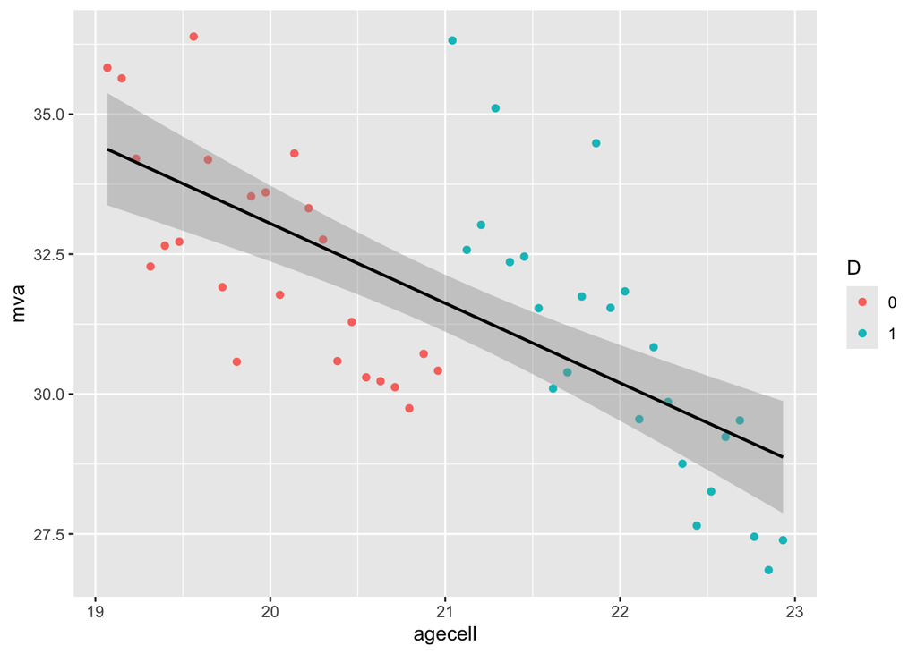

```r
data %>%
  select(agecell, mva) %>%
  mutate(D = as.factor(ifelse(agecell >= 21, 1, 0))) %>%
  ggplot(aes(x = agecell, y = mva)) +
  geom_point(aes(color = D)) +
  geom_smooth(method = "lm", colour = 'black', size = 0.8)
```

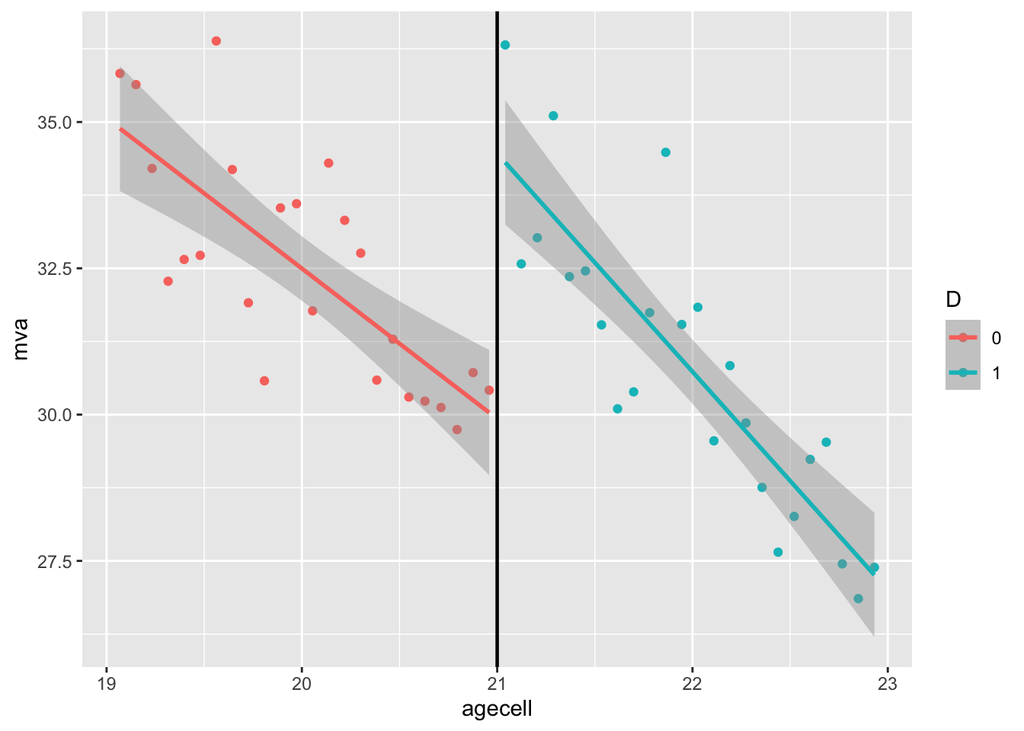

```r
data %>%
  select(agecell, mva) %>%
  mutate(D = as.factor(ifelse(agecell >= 21, 1, 0))) %>%
  ggplot(aes(x = agecell, y = mva, color = D)) +
  geom_point() +
  geom_smooth(method = "lm") +
  geom_vline(xintercept = 21, size = 0.8, colour = 'black')
```

## References

[GitHub](https://github.com/jrnold/masteringmetrics/tree/master/masteringmetrics/data)

Carpenter and Dobkin (2007)

Carpenter, Christopher, and Carlos Dobkin. 2007. “‚The Effects of Alcohol Consumption on Mortality: Regression Discontinuity from the Minimum Drinking Age,” National Bureau of Economic Research. https://doi.org/10.3386/w13374.